#Team 6: Paula, Sadiksha**

# 🧬 Capstone Project: R-based Mass Spectrometry Proteomics Workflow

#This document provides a step-by-step guide for your capstone project on analyzing proteomics data using R.

## 🔁 Workflow Overview

### 1. 📁 Dataset Acquisition  
#**Input:** PRIDE PXD Identifier

#(*Example: `PXD0123456`, accessible via [PRIDE](https://www.ebi.ac.uk/pride/)*)

#Use the `rpx` package to access metadata and download a dataset that includes `.mzID` files from a published study.

```r
#if (!require("BiocManager", quietly = TRUE))
#    install.packages("BiocManager")

#BiocManager::install("rpx")
#BiocManager::install("PSMatch")
#install.packages("dplyr")
#install.packages("ggplot2")
#install.packages("sessioninfo")
```

```r
library(rpx)
library(PSMatch)
```

```r
library(ggplot2)
library(dplyr)
library(sessioninfo)
```

```r
px <- PXDataset("PXD054877")  # Create a PXDataset object for the dataset with ID "PXD056514" #female
```

```
## Loading PXD054877 from cache.
```

```r
pxfiles(px) ## Retrieve and display a list of all files associated with the PXDataset object 'px'
```

```
## Project PXD054877 files (21):
##  [remote] 240417_Natalie_F1_01.msf
##  [remote] 240417_Natalie_F1_01.msfView
##  [remote] 240417_Natalie_F1_01.mzML
##  [local]  240417_Natalie_F1_01.mzid.gz
##  [remote] 240417_Natalie_F1_01.pdResult
##  [remote] 240417_Natalie_F1_01.pdResultView
##  [remote] 240417_Natalie_F1_01.raw
##  [remote] 240417_Natalie_F1_02.raw
##  [remote] 240417_Natalie_F2_01.raw
##  [remote] 240417_Natalie_F2_02.raw
##  ...
```

```r
files <- pxfiles(px) #Retrieve and display a list of all files associated with the PXDataset object 'px'
```

```
## Project PXD054877 files (21):
##  [remote] 240417_Natalie_F1_01.msf
##  [remote] 240417_Natalie_F1_01.msfView
##  [remote] 240417_Natalie_F1_01.mzML
##  [local]  240417_Natalie_F1_01.mzid.gz
##  [remote] 240417_Natalie_F1_01.pdResult
##  [remote] 240417_Natalie_F1_01.pdResultView
##  [remote] 240417_Natalie_F1_01.raw
##  [remote] 240417_Natalie_F1_02.raw
##  [remote] 240417_Natalie_F2_01.raw
##  [remote] 240417_Natalie_F2_02.raw
##  ...
```

```r
mzid_files <- pxget(px, grep("mzid", pxfiles(px))) #Identify the .mzID files from the retrieved files
```

```
## Project PXD054877 files (21):
##  [remote] 240417_Natalie_F1_01.msf
##  [remote] 240417_Natalie_F1_01.msfView
##  [remote] 240417_Natalie_F1_01.mzML
##  [local]  240417_Natalie_F1_01.mzid.gz
##  [remote] 240417_Natalie_F1_01.pdResult
##  [remote] 240417_Natalie_F1_01.pdResultView
##  [remote] 240417_Natalie_F1_01.raw
##  [remote] 240417_Natalie_F1_02.raw
##  [remote] 240417_Natalie_F2_01.raw
##  [remote] 240417_Natalie_F2_02.raw
##  ...
```

```
## Loading 240417_Natalie_F1_01.mzid.gz from cache.
```

### 2. 🧱 PSM Object Creation & Preprocessing

#**Goal:** Generate a PSM (Peptide-Spectrum Match) object from `.mzID` files

#- Convert `.mzID` files into `PSM` objects # Assess: # Number of decoy hits # Score distributions # PSM rank # Apply filtering based on FDR or identification score

```r
psms <- PSM(mzid_files, parser = 'mzID') #Convert .mzID files into PSM objects
```

```
## reading 1680e70c3ef72_240417_Natalie_F1_01.mzid.gz... DONE!
```

```r
names(psms)
```

```
##  [1] "spectrumid"                     "retention time"
##  [3] "acquisitionnum"                 "passthreshold"
##  [5] "rank"                           "experimentalmasstocharge"
##  [7] "calculatedmasstocharge"         "chargestate"
##  [9] "mascot:score"                   "proteomediscoverer:delta score"
## [11] "sequest:deltacn"                "sequest:xcorr"
## [13] "post"                           "pre"
## [15] "end"                            "start"
## [17] "accession"                      "length"
## [19] "description"                    "sequence"
## [21] "pepseq"                         "modified"
## [23] "modification"                   "idFile"
## [25] "spectrumFile"                   "databaseFile"
```

```r
# PSM rank
#    * Number of decoy hits
#no isdecoy column
psm_df <- tidyr::as_tibble(psms)
psm_df
```

```
## # A tibble: 57,251 × 26
##    spectrumid retention.time acquisitionnum passthreshold  rank
##    <chr>               <dbl>          <dbl> <lgl>         <dbl>
##  1 scan=5               6.51              5 TRUE              1
##  2 scan=12              9.93             12 TRUE              1
##  3 scan=12              9.93             12 TRUE              1
##  4 scan=12              9.93             12 TRUE              1
##  5 scan=12              9.93             12 TRUE              1
##  6 scan=12              9.93             12 TRUE              1
##  7 scan=14             10.2              14 TRUE              1
##  8 scan=14             10.2              14 TRUE              1
##  9 scan=14             10.2              14 TRUE              1
## 10 scan=14             10.2              14 TRUE              1
## # ℹ 57,241 more rows
## # ℹ 21 more variables: experimentalmasstocharge <dbl>,
## #   calculatedmasstocharge <dbl>, chargestate <dbl>, mascot.score <dbl>,
## #   proteomediscoverer.delta.score <dbl>, sequest.deltacn <dbl>,
## #   sequest.xcorr <dbl>, post <chr>, pre <chr>, end <dbl>, start <dbl>,
## #   accession <chr>, length <dbl>, description <chr>, sequence <chr>,
## #   pepseq <chr>, modified <lgl>, modification <chr>, idFile <chr>, …
```

```r
#Converted into dataframe because it is just easier to check in environment and easier to work on for me; for exploring and visualization only. we will do filtering in actual object psms in later steps
sum(is.na(psm_df$description)) #0 #one way is to check if there are proteins without description. -> No NAs in description
```

```
## [1] 0
```

```r
#Another idea we discussed was that if the peak score is low (for eg 0), they could be removed as decoy. So I will come back to that in later step after score distribution
```

```r
#    * Number of decoy hits
#no isdecoy column
#Converted into tibble because it is just easier to check in environment and easier to work on for me. as  hist script :)
sum(is.na(psm_df$description)) #0 #one way is to check if there are proteins without description. -> No NAs in description
```

```
## [1] 0
```

```r
#Another idea we discussed was that if the peak score is low (for eg 0), they could be removed as decoy. So I will come back to that in later step after score distribution
```

```r
#Score distributions
# Score distributions
score_distribution <- summary(psms@listData$`mascot:score`)
print(score_distribution)
```

```
##    Min. 1st Qu.  Median    Mean 3rd Qu.    Max.    NA's
##    0.00   27.00   41.00   44.06   58.00  200.00   19209
```

```r
#hist(psms@listData$`mascot:score`, breaks = 100) #one way to do histogram

table(psm_df$passthreshold) #true#57251 may be after removing decoys or delta score or mascot score thereshold?
```

```
##
##  TRUE
## 57251
```

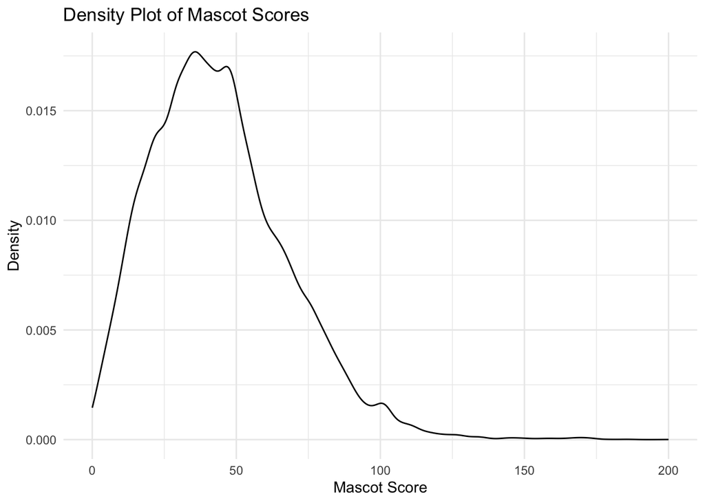

```r
ggplot(psm_df, aes(x = mascot.score)) +
  geom_density()+
   labs(title = "Density Plot of Mascot Scores",
       x = "Mascot Score",
       y = "Density") +
  theme_minimal()
```

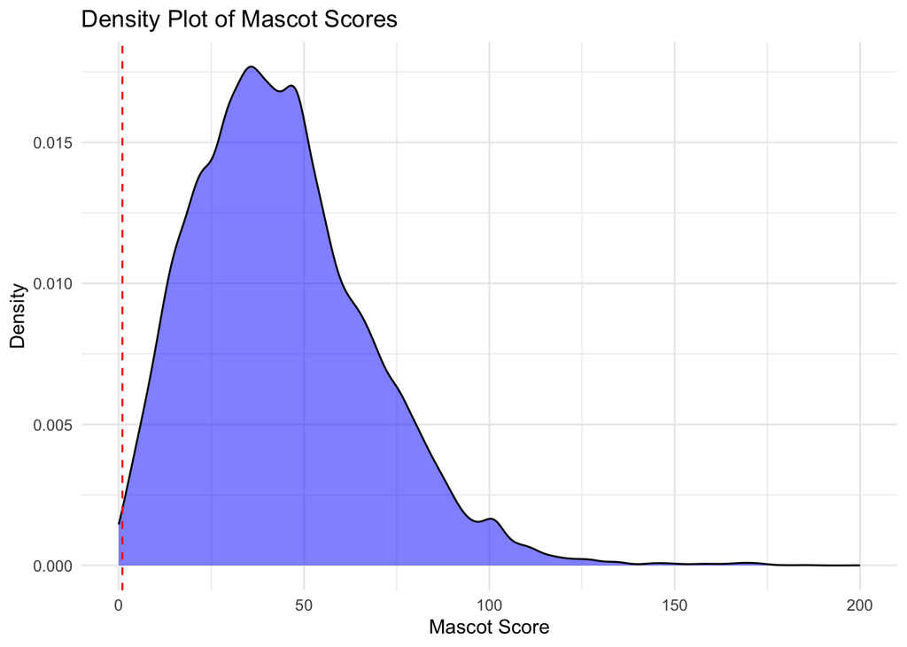

```r
#when filtering one plan is to remove everything at 0. just exploring where to filter
ggplot(psm_df, aes(x = mascot.score)) +
  geom_density(fill = "blue", alpha = 0.5) +  # Fill color for the density plot
  geom_vline(xintercept = 1, linetype = "dashed", color = "red") +  # Vertical line at x = 1
  labs(title = "Density Plot of Mascot Scores",
       x = "Mascot Score",
       y = "Density") +
  theme_minimal()
```

```r
# PSM rank
psm_rank_distribution <- table(psm_df$rank)
print(psm_rank_distribution) #we dont have many that have higher rank
```

```
##
##     1     2     3     4     6     7     9
## 56215   969    61     1     2     2     1
```

```r
#Apply filtering based on FDR or identification score ?
psms <- psms %>% filterPsmRank() #keeping only those with rank 1
```

```
## Removed 1036 PSMs with rank > 1.
```

```r
psms <- filterPsmFdr(psms, FDR = 0.05, fdr = psmVariables(psms)["fdr"], verbose = TRUE) #if we had fdr column, we don't have that column
psm_df <- tidyr::as_tibble(psms)
orig_df <- nrow(psm_df)
psm_df <- psm_df %>% filter(mascot.score > 0) #filtering based on identification score becuase we do not have decoys adn fdr in this data
filtered_df <- nrow(psm_df)
number_of_decoys <- orig_df -filtered_df
(number_of_decoys)
```

```
## [1] 19093
```

```r
adjacencyMatrix(psms)
```

```
## 1817 x 464 sparse Matrix of class "dgCMatrix"
```

```
##   [[ suppressing 32 column names 'P04264', 'Q6IFW7', 'P13645' ... ]]
```

[output not shown]

[output cut: 10856 more lines]

[output not shown]